# proj

Yinglu Deng

10/18/2021

## Beijing PM2.5 Dataset Exploring

This hourly dataset contains the PM2.5 data of US Embassy in Beijing. Meanwhile, meteorological data from Beijing Capital International Airport are also included. (Source from https://archive-beta.ics.uci.edu/ml/datasets/beijing+pm2+5+data)

PM2.5 is a 2.5 micrometers or less than 2.5 particle pollutant exposure in the air. It increased hospital admissions for heart or lung causes, acute and chronic bronchitis.

### Attribute Information:

year: year of data in this row month: month of data in this row day: day of data in this row hour: hour of data in this row pm2.5: PM2.5 concentration (ug/m^3) DEWP: Dew Point (â„ƒ) TEMP: Temperature (â„ƒ) PRES: Pressure (hPa) cbwd: Combined wind direction Iws: Cumulated wind speed (m/s) Is: Cumulated hours of snow Ir: Cumulated hours of rain

```r
# comment out after installation
#install.packages('raster')
#install.packages('ggmap')
#install.packages('viridis')
#install.packages('scales')

# load packages
library(ggmap)
library(raster)
library(scales)
library(viridis)
library(tidyverse)
library(patchwork)
library(dplyr)
library(MARSS)
library(forecast)
myData <- read.csv("PRSA_data_2010.1.1-2014.12.31.csv")
head(myData)
```

```
##   No year month day hour pm2.5 DEWP TEMP PRES cbwd   Iws Is Ir
## 1  1 2010     1   1    0    NA  -21  -11 1021   NW  1.79  0  0
## 2  2 2010     1   1    1    NA  -21  -12 1020   NW  4.92  0  0
## 3  3 2010     1   1    2    NA  -21  -11 1019   NW  6.71  0  0
## 4  4 2010     1   1    3    NA  -21  -14 1019   NW  9.84  0  0
## 5  5 2010     1   1    4    NA  -20  -12 1018   NW 12.97  0  0
## 6  6 2010     1   1    5    NA  -19  -10 1017   NW 16.10  0  0
```

```r
#view(myData)

#completeness
missing_data_pm <- myData[!complete.cases(myData$pm2.5),]
round((dim(missing_data_pm)[1] / dim(myData)[1]) * 100, digit=0)
```

```
## [1] 5
```

```r
#basic descriptive statistics for each time series (at least mean, CV, ACF for each variable)
nrow(myData)   #rows in total
```

```
## [1] 43824
```

```r
summary(myData)   # summarize data: min, mean, max, NAs
```

```
##        No             year          month             day
##  Min.   :    1   Min.   :2010   Min.   : 1.000   Min.   : 1.00
##  1st Qu.:10957   1st Qu.:2011   1st Qu.: 4.000   1st Qu.: 8.00
##  Median :21912   Median :2012   Median : 7.000   Median :16.00
##  Mean   :21912   Mean   :2012   Mean   : 6.524   Mean   :15.73
##  3rd Qu.:32868   3rd Qu.:2013   3rd Qu.:10.000   3rd Qu.:23.00
##  Max.   :43824   Max.   :2014   Max.   :12.000   Max.   :31.00
##
##       hour           pm2.5             DEWP              TEMP
##  Min.   : 0.00   Min.   :  0.00   Min.   :-40.000   Min.   :-19.00
##  1st Qu.: 5.75   1st Qu.: 29.00   1st Qu.:-10.000   1st Qu.:  2.00
##  Median :11.50   Median : 72.00   Median :  2.000   Median : 14.00
##  Mean   :11.50   Mean   : 98.61   Mean   :  1.817   Mean   : 12.45
##  3rd Qu.:17.25   3rd Qu.:137.00   3rd Qu.: 15.000   3rd Qu.: 23.00
##  Max.   :23.00   Max.   :994.00   Max.   : 28.000   Max.   : 42.00
##                  NA's   :2067
##       PRES          cbwd                Iws               Is
##  Min.   : 991   Length:43824       Min.   :  0.45   Min.   : 0.00000
##  1st Qu.:1008   Class :character   1st Qu.:  1.79   1st Qu.: 0.00000
##  Median :1016   Mode  :character   Median :  5.37   Median : 0.00000
##  Mean   :1016                      Mean   : 23.89   Mean   : 0.05273
##  3rd Qu.:1025                      3rd Qu.: 21.91   3rd Qu.: 0.00000
##  Max.   :1046                      Max.   :585.60   Max.   :27.00000
##
##        Ir
##  Min.   : 0.0000
##  1st Qu.: 0.0000
##  Median : 0.0000
##  Mean   : 0.1949
##  3rd Qu.: 0.0000
##  Max.   :36.0000
##
```

```r
# create a column with month as a factor instead of integer
myData1 <- myData %>%
  mutate(month_fac=factor(month)) # an ordered category
head(myData1)
```

```
##   No year month day hour pm2.5 DEWP TEMP PRES cbwd   Iws Is Ir month_fac
## 1  1 2010     1   1    0    NA  -21  -11 1021   NW  1.79  0  0         1
## 2  2 2010     1   1    1    NA  -21  -12 1020   NW  4.92  0  0         1
## 3  3 2010     1   1    2    NA  -21  -11 1019   NW  6.71  0  0         1
## 4  4 2010     1   1    3    NA  -21  -14 1019   NW  9.84  0  0         1
## 5  5 2010     1   1    4    NA  -20  -12 1018   NW 12.97  0  0         1
## 6  6 2010     1   1    5    NA  -19  -10 1017   NW 16.10  0  0         1
```

```r
#view(myData1)

# definition: The coefficient of variation (CV) is the ratio of the standard deviation to the mean. The higher the coefficient of variation, the greater the level of dispersion around the mean. It is generally expressed as a percentage.
CV <- function(x, ...){(sd(x, ...)/mean(x, ...))*100} # specify a function for CV

## calculate means and CVs with NAs removed using the na.rm=T argument
myData2 <- myData1 %>%
  group_by(month_fac) %>%
  summarize(pm2.5_mean=mean(pm2.5, na.rm=T), pm2.5_CV=CV(pm2.5, na.rm=T))
summary(myData2)
```

```
##    month_fac   pm2.5_mean        pm2.5_CV
##  1      :1   Min.   : 80.00   Min.   : 68.07
##  2      :1   1st Qu.: 84.83   1st Qu.: 71.49
##  3      :1   Median : 97.14   Median : 87.54
##  4      :1   Mean   : 98.57   Mean   : 86.87
##  5      :1   3rd Qu.:108.09   3rd Qu.: 97.31
##  6      :1   Max.   :125.74   Max.   :111.52
##  (Other):6
```

```r
#view(myData2)

myData_day <- myData %>%
  group_by(year, month, day) %>%
  summarize(pm2.5_mean=mean(pm2.5, na.rm=T), pm2.5_CV=CV(pm2.5, na.rm=T))
summary(myData_day)
```

```
##       year          month             day          pm2.5_mean
##  Min.   :2010   Min.   : 1.000   Min.   : 1.00   Min.   :  2.958
##  1st Qu.:2011   1st Qu.: 4.000   1st Qu.: 8.00   1st Qu.: 42.231
##  Median :2012   Median : 7.000   Median :16.00   Median : 79.167
##  Mean   :2012   Mean   : 6.524   Mean   :15.73   Mean   : 98.653
##  3rd Qu.:2013   3rd Qu.:10.000   3rd Qu.:23.00   3rd Qu.:131.167
##  Max.   :2014   Max.   :12.000   Max.   :31.00   Max.   :552.478
##                                                  NA's   :37
##     pm2.5_CV
##  Min.   :  1.252
##  1st Qu.: 26.777
##  Median : 39.541
##  Mean   : 47.070
##  3rd Qu.: 60.077
##  Max.   :227.003
##  NA's   :40
```

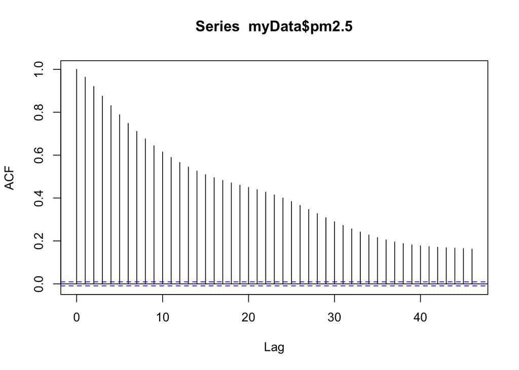

```r
#view(myData_day)

date <-seq(lubridate::as_date("2010-1-1"), lubridate::as_date("2014-12-31"), by = "days")
#view(data)
myData_day <- myData_day %>%
              add_column(date = date)
#view(myData_day)

# Plot an ACF of the ozone time series
#plot.ts(myData$pm2.5, main='PM2.5 Time Series', col = "purple", ylab = "PM2.5")

acf(myData$pm2.5, na.action = na.pass)
```

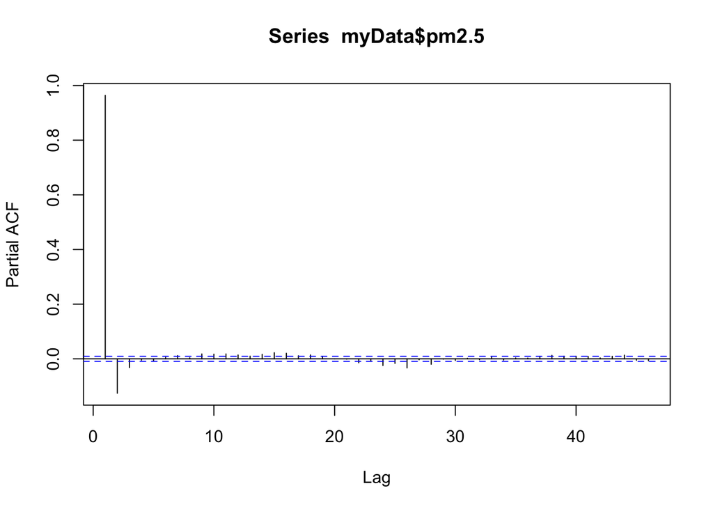

```r
pacf(myData$pm2.5, na.action = na.pass)
```

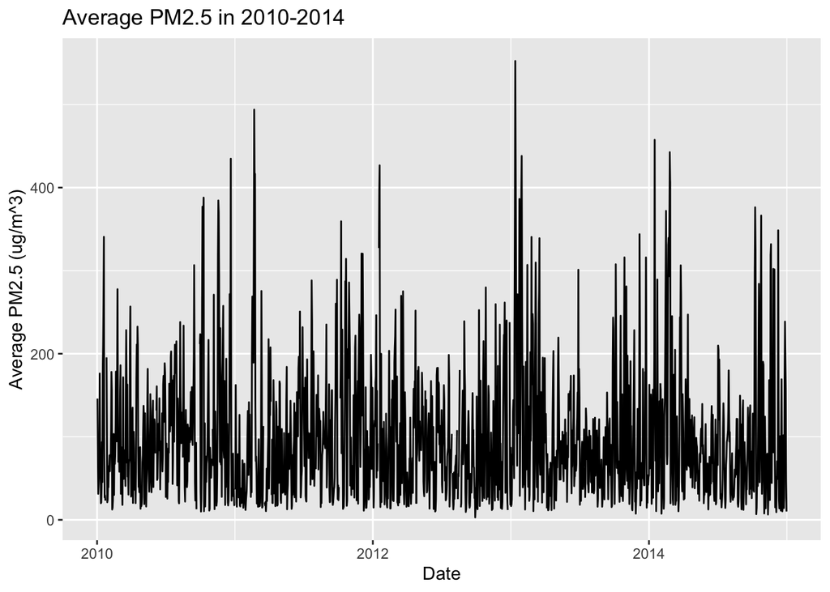

```r
p=myData_day%>%
  ggplot(aes(date,pm2.5_mean))+
  geom_line()+
  labs(title="Average PM2.5 in 2010-2014",x="Date", y = "Average PM2.5 (ug/m^3)")
print(p)
```

# Q1: What is the day of average highest pm2.5 in each month?

```r
month_day <-seq(lubridate::as_date("0000-1-1"), lubridate::as_date("0000-12-31"), by = "days")
myData_month_day <- myData %>%
  group_by(month, day) %>%
  summarize(pm2.5_mean=mean(pm2.5, na.rm=T), pm2.5_CV=CV(pm2.5, na.rm=T))
summary(myData_month_day)
```

```
##      month             day          pm2.5_mean        pm2.5_CV
##  Min.   : 1.000   Min.   : 1.00   Min.   : 31.78   Min.   : 22.59
##  1st Qu.: 4.000   1st Qu.: 8.00   1st Qu.: 72.96   1st Qu.: 63.41
##  Median : 7.000   Median :16.00   Median : 92.23   Median : 77.15
##  Mean   : 6.514   Mean   :15.76   Mean   : 98.81   Mean   : 79.15
##  3rd Qu.: 9.750   3rd Qu.:23.00   3rd Qu.:115.62   3rd Qu.: 90.21
##  Max.   :12.000   Max.   :31.00   Max.   :271.88   Max.   :171.58
```

```r
myData_month_day <- myData_month_day %>%
              add_column(month_day = month_day)
view(myData_month_day)

myData_day
```

```
## # A tibble: 1,826 × 6
## # Groups:   year, month [60]
##     year month   day pm2.5_mean pm2.5_CV date
##    <int> <int> <int>      <dbl>    <dbl> <date>
##  1  2010     1     1      NaN       NA   2010-01-01
##  2  2010     1     2      146.      13.3 2010-01-02
##  3  2010     1     3       78.8     18.2 2010-01-03
##  4  2010     1     4       31.3     38.8 2010-01-04
##  5  2010     1     5       42.5     48.7 2010-01-05
##  6  2010     1     6       56.4     59.1 2010-01-06
##  7  2010     1     7       69       76.8 2010-01-07
##  8  2010     1     8      176.      35.2 2010-01-08
##  9  2010     1     9       88.5     58.7 2010-01-09
## 10  2010     1    10       57.2     40.3 2010-01-10
## # … with 1,816 more rows
```

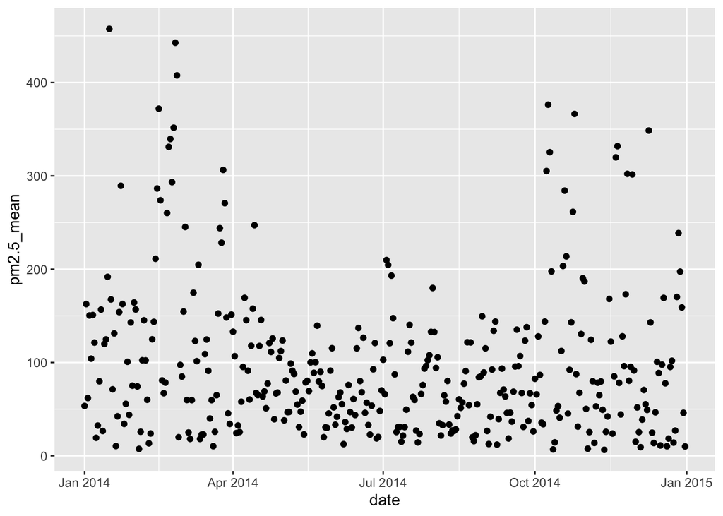

```r
Data_2014 <- filter(myData_day, year == 2014)
#view(myData_day)
#ggplot(myData_month_day, mapping = aes(x=month_day, y=pm2.5_mean)) + geom_point()
ggplot(Data_2014, mapping = aes(x=date, y=pm2.5_mean)) + geom_point()
```

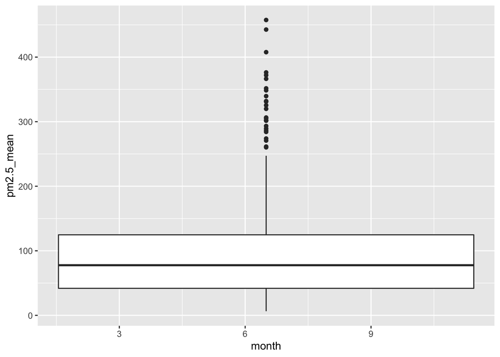

```r
p<-ggplot(Data_2014, aes(x=month, y=pm2.5_mean)) +
  geom_boxplot()
p
```

```r
#p <- ggplot(myData_day, aes(x=pm2.5_mean, color=day)) +
#  geom_density()+
#  labs(title="PM2.5 Density Curve based on Season",x="PM2.5 concentration (ug/m^3)", y = "Density")
#p

# p <- ggplot(data=myData_day, aes(x=day, y=pm2.5_mean)) +
#  geom_bar(stat="identity")
# p

# third week will be the worse of the the whole month?
#x-axis --year
```

# Q2.Which season has severer pm2.5 problem in a year? (daliy) auto.arima;forecast R package

```r
#view(myData)

myData$season[myData$month == 3 | myData$month == 4 | myData$month == 5] = "Spring"
myData$season[myData$month == 6 | myData$month == 7 | myData$month == 8] = "Summer"
myData$season[myData$month == 9 | myData$month == 10 | myData$month == 11] = "Autumn"
myData$season[myData$month == 12 | myData$month == 1 | myData$month == 2] = "Winter"

#view(myData)

myData_day2 <- myData %>%
  group_by(season) %>%
  summarize(pm2.5_mean=mean(pm2.5, na.rm=T), pm2.5_CV=CV(pm2.5, na.rm=T))
summary(myData_day2)
```

```
##     season            pm2.5_mean        pm2.5_CV
##  Length:4           Min.   : 87.21   Min.   : 70.95
##  Class :character   1st Qu.: 89.63   1st Qu.: 80.91
##  Mode  :character   Median : 97.33   Median : 89.60
##                     Mean   : 98.66   Mean   : 88.96
##                     3rd Qu.:106.36   3rd Qu.: 97.66
##                     Max.   :112.78   Max.   :105.69
```

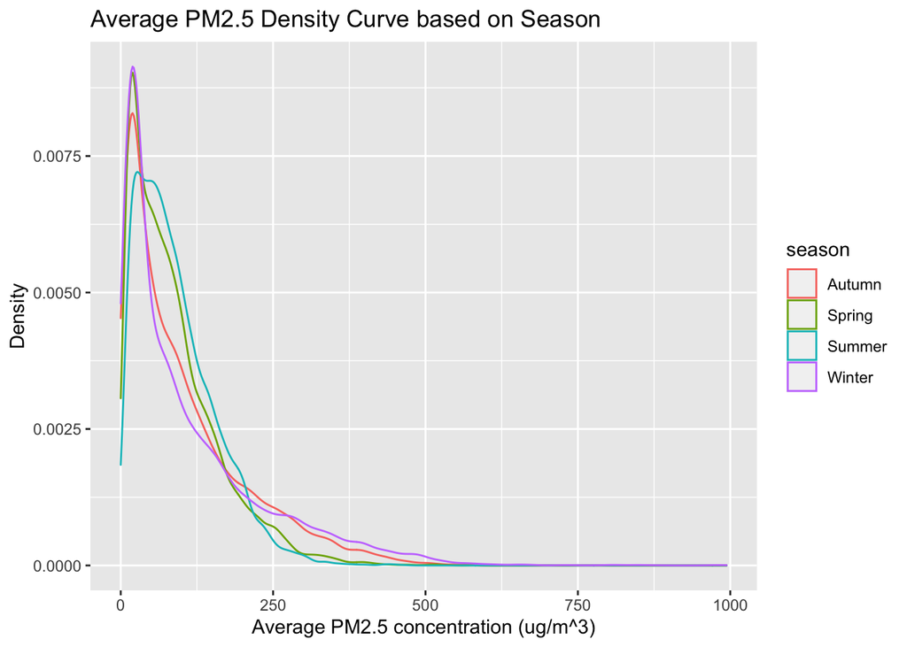

```r
view(myData_day2)

#view(myData)

# winter mean is higher on the table
p <- ggplot(myData, aes(x=pm2.5, color=season)) +
  geom_density()+
  labs(title="Average PM2.5 Density Curve based on Season",x="Average PM2.5 concentration (ug/m^3)", y = "Density")
p
```

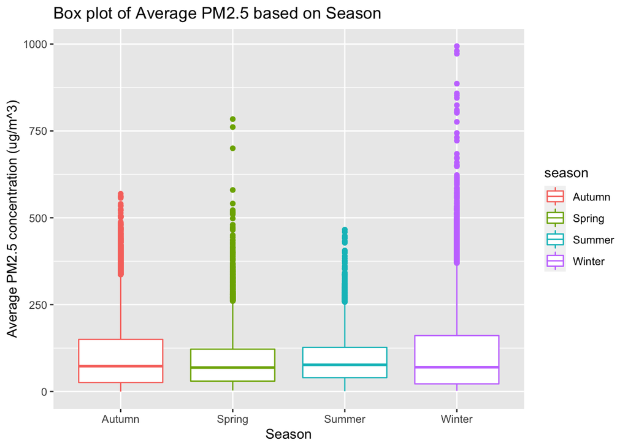

```r
p<-ggplot(myData, aes(x=season, y=pm2.5, color=season)) +
  geom_boxplot()+
  labs(title="Box plot of Average PM2.5 based on Season",y="Average PM2.5 concentration (ug/m^3)", x = "Season")
p
```

```r
# Add mean line
#p + geom_vline(data=myData_day2, aes(xintercept=pm2.5_mean),
 #           color=season, linetype="dashed")
```